# Mapinguari

Gabriel Caetano, Juan Santos, Barry Sinervo

2017-08-02

It is well documented that climate change has severe effects on biodiversity. Species distribution models or SDMs are popular tools for predicting individual species distributions and project the effects of climate change on those distributions, under different scenarios. Most SDMs are correlative and do not take into account biological processes underlying species responses to environmental variables. We aim to provide a modeling tool to fulfill this gap by estimating geographical layers with biologically relevant information that can be used in SDMs or other biogeographical analysis, as well as stimulating good practices in dealing with spatial autocorrelation, predictor selection, model evaluation, consensus and comparison.

Mapinguari is an add-on package for program R aimed at providing tools to facilitate the incorporation of biological processes in biogeographical analyses. It offers conveniences in fitting, comparing and extrapolating models of biological processes such as physiology, phenology, adaptation, interspecific interactions, demography and dispersal. These spatial extrapolations can be informative by themselves, but also complement traditional correlative SDM methods, by mixing purely environmental and process-based predictors.

On this manual I will provide some examples of the kind of information that can be generated with Mapinguari, using a terrestrial ectotherm and processes relevant to those animals as examples, such as temperature limited activity times and locomotor performance. The spatial information that can be generated with the package is not limited to those presented here, and the same principles apply to generating surfaces relevant to other taxa, such as metabolic rates, time inside thermal neutral zone, photosyntesis, seed and egg development rates, etc.

## Installation

The package is currently hosted on GitHub, this is how to install and load it:

```r
# You need package devtools to install packages from GitHub
library(devtools)

#install_github("gabrielhoc/Mapinguari")
load_all(".")

#library(Mapinguari)
```

Next, we are going to give an example of how to use the package, using some simulated data:

# The fate of *Fulanus*

*Fulanus beltranus* is a fictional species of lizard from Democratic Republic of Congo. We would like to find out how this species is going to do in different climate change scenarios. First let’s look at the points where it is currently known to occurr. To access the table with distribution data `FulanusDistribution`, package Mapinguari has to be loaded. Here we use ggmap to plot the points over a image from Google Maps (copyright Google).

```r
# Load ggmap and ggplot2 to make the map
library(ggmap)
library(ggplot2)

Fulanus_bbox <- make_bbox(lat = Lat,
  lon = Lon,
  data = FulanusDistribution,
  f = 0.2)

Fulanus_big <- get_map(location = Fulanus_bbox,
  source = "google",
  maptype = "terrain")

ggmap(Fulanus_big) +
  geom_point(data = FulanusDistribution,
    mapping = aes(x = Lon, y = Lat),
    size = 1,
    colour = 'red')
```

[output not shown]

Now, let’s get some information on the climate of this region.

## Obtaining rasters

We can use function `get_rasters` to extract WorldClim surfaces for that area. The argument `ext` tells us which is the area you desire to crop your rasters around. It accepts either a numerical vector with the coordinates of cropping limits (in order: western most longitude, easter most longitude, southern most latitude then northern most latitude), or a table of longitudes and latitudes, in which case it will grab the coordinates of the most extreme points and use those as the cropping limits. The argument `margin` adds to these limits, and it is on the same unit as the coordinates you supply.

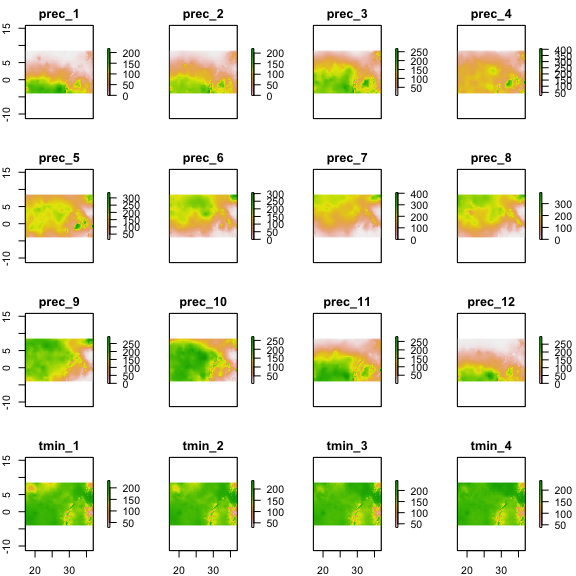

```r
# library(Mapinguari)
library(raster)

FulanusEcoRasters_present <-
   get_rasters(
     raster_source = "/Users/gabriel/Documents/Mapinguari/global_grids_10_minutes",
     ext = FulanusDistribution,
     margin = 5,
     non_fixed_var = c('prec', 'tmin', 'tmax'),
     fixed_var = 'alt',
     years = c("present"),
     reorder = TRUE)

plot(FulanusEcoRasters_present[[1]])
```

`get_rasters` is able to download rasters from WorldClim if you leave `raster_source` blank, but you probably don’t want to download them every time you are executing the function. That’s why the argument `raster_source` will also take a list of rasters from your workspace or a path to a folder containing those rasters. These options also have the advantage of being able to input any raster you want, not being limited to the ones you can download from WorldClim.

However, in order for Mapinguari to recognize which variables correspond to each year or scenario, you have to name your folders and list elements following the convention *variable_year_scenario*. The default character for separating those terms is “_“, but you can change that, as long as you do the corresponding change to the argument `separator` in the function. Some of your rasters will not be subject to scenarios, since they are measures of current climate, instead of projections. In that case you only have to name their folders *variable_year*, omitting the scenario term. The argument `baseline` identifies which years are not subject to scenarios. The default for this argument is `present`, but it can be changed at your convenience. Some other variables are constant accross the time considered, such as altitude. In that case you only have to write the name of the variable. Here is an example of how my folder is structured:

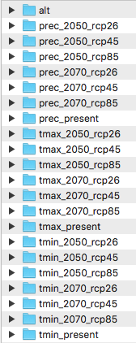

I’m going to assign the path to that directory to an object:

```r
my_directory <- "/Users/gabriel/Documents/Mapinguari/global_grids_10_minutes"
```

Why did I place some variables in the `non-fixed` argument and others in the `fixed` argument? Variables on `non_fixed` are things such as climate, which you expect to change in different times and future scenarios, while variables in `fixed` are things such as geological features, which you expect to remain constant accross the time projected.

Another important argument for non-fixed variables is `reorder`, which will take the last two characters of your RasterLayer names, replace letters with zeros and order the layers in ascending order of those numbers. This is useful because of the way some of the WorldClim layers are named when you download them, which when stacked will be placed out of chronological order. This argument fixes that. But be careful if you are using layers with different names than the ones from WorldClim. If they are in the correct order when you stack them, `reorder` could scramble them, so set it to FALSE.

Let’s try getting some projections for the future years of 2050 and 2070:

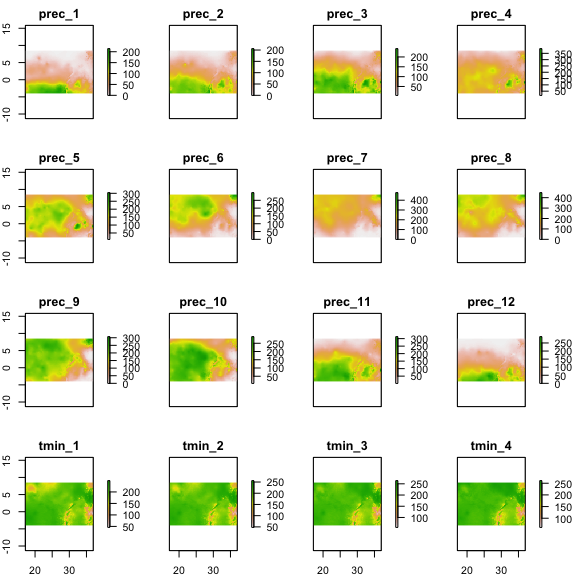

```r
FulanusEcoRasters_future <-
   get_rasters(
     raster_source = my_directory,
     ext = FulanusDistribution,
     margin = 5,
     non_fixed_var = c('prec', 'tmin', 'tmax'),
     years = c('2050', '2070'),
     scenarios = c('rcp26', 'rcp45', 'rcp85'),
     reorder = TRUE)

plot(FulanusEcoRasters_future$`2050_rcp26`)
```

As you can see, we have multiple rasters for each variable, one for each month. When doing biogeographical analysis, such as species distribution models, it is common to need a summary raster for each variable, such as the annual average or total. Function `transform_rasters` can help us to get summaries for the whole year or for parts of the year.

## Summarizing time-varying rasters

Function `transform_rasters` allows us to apply any vectorized function to any subset of rasters for each variable, so we can get measures like averages, standard deviations, totals, variance or any other summary function for the month layers. Summaries have the advantage of reducing computation time, as they allows us to work with less layers. The first argument is `raster_stack`, which is where we supply the RasterStack with the layers for the calculations. The second argument, `FUN_qlist`, is where we supply the functions to be applied, the variables to apply the functions to, as well as the subset of the layers for that variable that will be included in the calculation. This expressions have to be inside a `qlist`, which is a list that returns its arguments unevaluated. In order for the function to find the layers, the layer names must begin with the same variable name used in the `FUN_qlist` expressions, before the separator character.

```r
Fulanus_present_year_summaries <-
   transform_rasters(FulanusEcoRasters_present$present,
    FUN_qlist = qlist(tmax_average_year = mean(tmax),
                      tmax_sd_year = sd(tmax),
                      tmin_average_year = mean(tmin),
                      tmin_sd_year = sd(tmin),
                      prec_total_year = sum(prec)))

# The function operates in RasterStacks, if you want to apply it to a list, you can use `lapply`:

Fulanus_future_year_summaries <-
lapply(FulanusEcoRasters_future, transform_rasters,
    FUN_qlist = qlist(tmax_average_year = mean(tmax),
                      tmin_average_year = mean(tmin)))

# You can also specify different subsets of the year to get, for example, summaries for seasons of the year, by using double square brackets.

Fulanus_present_two_seasons_summaries <-
   transform_rasters(FulanusEcoRasters_present$present,
    FUN_qlist = qlist(tmax_average_breeding = mean(tmax[[3:8]]),
                      tmax_average_growing = mean(tmax[[c(7:12, 1:3)]])))

plot(Fulanus_present_year_summaries$tmax_average_year)
```

[output not shown]

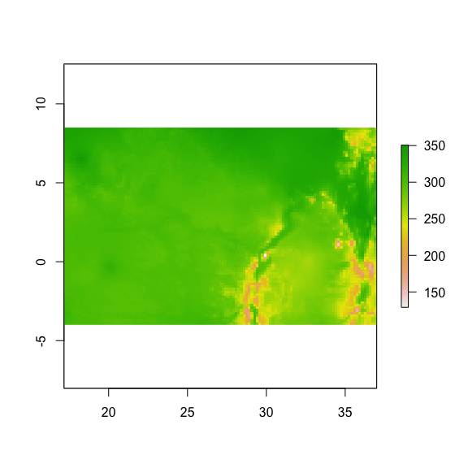

```r
plot(Fulanus_present_two_seasons_summaries$tmax_average_breeding)
```

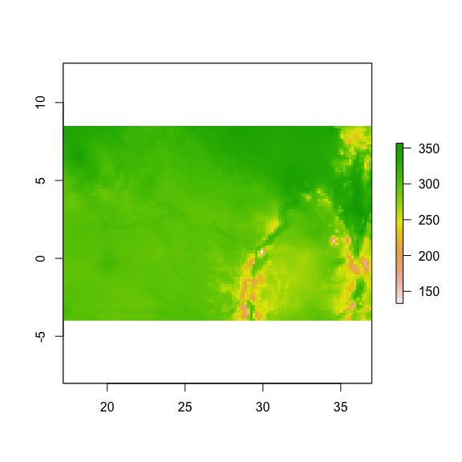

```r
plot(Fulanus_present_two_seasons_summaries$tmax_average_growing)
```

Summary functions are an useful example, but we can apply more complex functions, such as models using the spatial variables you have, in order to create new variables. But before we create those layers, we must fit the models in question. Function `fit_curves` allows us to fit models, compare them and get a vectorized function which returns the prediction of the model given the necessary variables.

## Fitting physiological models

Function `fit_curves` can be used to compare models with different parameterizations or specifications for your biological processes. The user needs to inform a list of models in argument `models` and the function will output a table with their AIC, BIC, log likelihood, delta AIC, delta BIC and a rank for AIC and BIC values. The main goal of the function, however, is to create vectorized predict functions for each model, which can then be used in `transform_models` to spatially extrapolate the model. In order to make the spatial extrapolation possible, you must have spatial information for at least one of the variables on the right hand side of your model formula. The vectorized function generated can be used to get predictions of your model in contexts other than spatial, such as for time series or specific values.

Back to *Fulanus*, we measured the maximum running speed of several individuals under different temperatures. We also recorded their body sizes, since that is a variable that is very likely to inffluence their performance. Here is how the data look like:

```r
head(FulanusPhysiology)
```

```
##             species   id temp performance  size    site acctemp hydration
## 1 Fulanus_beltranus 2412    3       22.26 1.994 Cafundo      10     0.825
## 2 Fulanus_beltranus 2015    3       24.30 3.327 Cafundo      10     0.825
## 3 Fulanus_beltranus 2122    3       25.02 2.658 Cafundo      10     0.825
## 4 Fulanus_beltranus 2220    3       25.44 2.346 Cafundo      10     0.825
## 5 Fulanus_beltranus 2022    3       26.04 3.006 Cafundo      10     0.775
## 6 Fulanus_beltranus 2212    3       26.82 2.504 Cafundo      10     0.775
```

Note that we also attributed a number to each lizard to keep track of which lizard did which trial. That is important because, since the same lizard ran different trials, the data points are not independent and we have to account for that when building our model.

Argument `models` can be a single model or a list of models. In this case we are fitting GAMM models, which can account for the autocorrelation from running several tests with each individual. You can name the models by putting their names on the list. Most model algorithms that have a method for function `predict` should work.

```r
library(mgcv)
```

```r
# Here is an example without naming the models. They will be assigned a generic name.
perf_functions_no_name <-
  fit_curves(gamm(performance ~ s(temp, bs = 'cs') + size,
                  random = list(id = ~ 1),
                  data = FulanusPhysiology))
```

```
##            logLik      AIC      BIC dAIC dBIC rankAIC rankBIC
## model_1 -2934.343 5878.686 5901.304    0    0       1       1
```

```r
# It is easier to keep track if you name them something meaningful (TPC means thermal performance curve). Also, you can fit multiple models at the same time.
perf_functions <-
  fit_curves(list(tpc_gamm_size = gamm(performance ~ s(temp, bs = 'cs') + size,
                                       random = list(id = ~ 1),
                                       data = FulanusPhysiology),
                  tpc_gamm_no_size = gamm(performance ~ s(temp, bs = 'cs'),
                                          random = list(id = ~ 1),
                                          data = FulanusPhysiology)))
```

```
##                     logLik      AIC      BIC     dAIC     dBIC rankAIC
## tpc_gamm_size    -2934.343 5878.686 5901.304  0.00000  0.00000       1
## tpc_gamm_no_size -2951.518 5911.035 5929.129 32.34875 27.82518       2
##                  rankBIC
## tpc_gamm_size          1
## tpc_gamm_no_size       2
```

The function prints a table containing statistics on each model, for comparison, and outputs a list containing that table, as well as a sub list for each model, containing the predictor function, raw model output and inputed arguments.

```r
perf_functions$stats
perf_functions$tpc_gamm_size$predict
perf_functions$tpc_gamm_size$model
perf_functions$tpc_gamm_size$output
```

You can assign the predictor function to a name, which can be applied to any value.

```r
my_tpc <- perf_functions$tpc_gamm_size$predict
my_tpc(temp = 20, size = 3)
```

```
##        1
## 76.27046
```

```r
# You can apply it to a vector
my_tpc(temp = 20:40, size = 3)
```

```
##         1         2         3         4         5         6         7
##  76.27046  79.04413  81.34007  82.99379  84.03314  84.57768  84.74755
##         8         9        10        11        12        13        14
##  84.66288  84.44381  84.21046  84.08298  84.18262  84.69811  85.92279
##        15        16        17        18        19        20        21
##  88.15899  91.70904  96.87525 103.95998 112.26919 109.52650  79.17918
```

The predictor function can be applied to rasters of the variables on the right hand side of the model formula to spatialize the variable on the right hand side. On the next section we are going to give an example.

## Spatialize a physiological model

`transform_rasters` can do the link between your physiological model and your spatial environmental data. The predictor functions obtained in `fit_curves` can be used in the same way we used the summary functions in the previous examples. This interface also allows us to set values for terms in the model, such as estimating performance for animals of specific sizes, in the thermal performance model we fitted before.

Note, however, that the variables on the rasters used need to be on the same scale as the data you used to fit the models. In this case, the raster temperatures are multiplied by 10, so we have to fix that first.

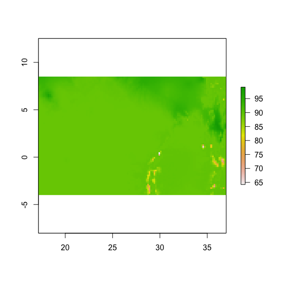

```r
# Let's scale the tmin and tmax average layers
FulanusEcoRasters_present_temps <- Fulanus_present_year_summaries[[c(1,3)]]/10

# You can calculate the performance for minimum and maximum temperatures, by changing the term on the expression inside FUN_qlist

Perf_rasters_tmax <-
  transform_rasters(raster_stack = FulanusEcoRasters_present_temps,
                    FUN_qlist = qlist(perf_tmax = my_tpc(tmax, size = mean(FulanusPhysiology$size))))

Perf_rasters_tmin <-
  transform_rasters(raster_stack = FulanusEcoRasters_present_temps,
                    FUN_qlist = qlist(perf_tmin = my_tpc(tmin, size = mean(FulanusPhysiology$size))))

# We can get the performance for individuals of different ages by changing the `size` argument on the my_tpc function (lizards' ages are highly correlated with size)

Perf_rasters_young <-
  transform_rasters(raster_stack = FulanusEcoRasters_present_temps,
                    FUN_qlist = qlist(perf_young = my_tpc(tmax, size = min(FulanusPhysiology$size))))

Perf_rasters_old <-
  transform_rasters(raster_stack = FulanusEcoRasters_present_temps,
                    FUN_qlist = qlist(perf_old = my_tpc(tmax, size = max(FulanusPhysiology$size))))

plot(Perf_rasters_tmax$perf_tmax)
```

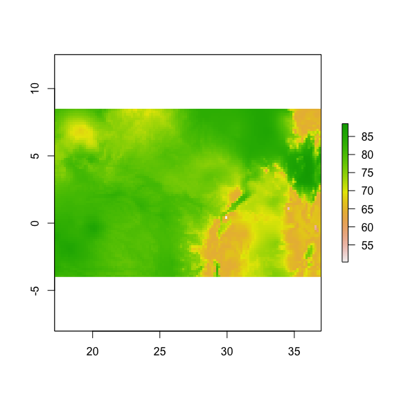

```r
plot(Perf_rasters_tmin$perf_tmin)
```

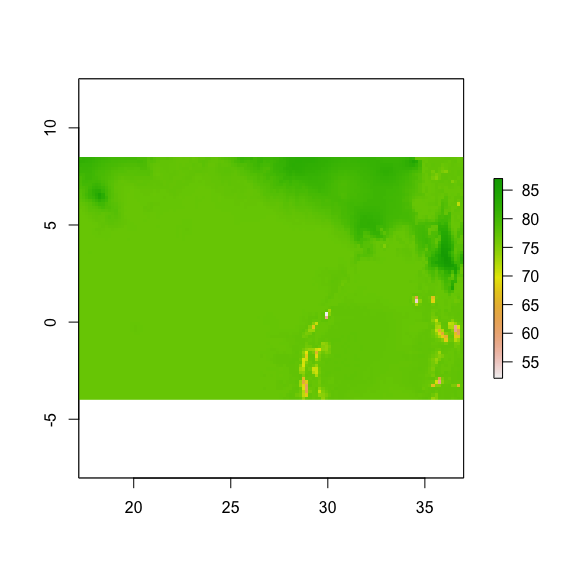

```r
plot(Perf_rasters_young$perf_young)
```

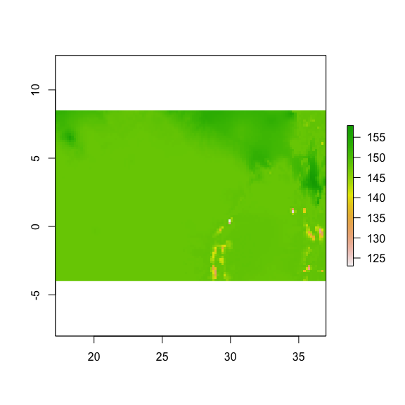

```r
plot(Perf_rasters_old$perf_old)
```

The function operates in RasterStacks, if you want to apply it to a list, you can use `lapply`:

```r
# First, scale the temperature rasters for future projections
FulanusEcoRasters_future_temps <- lapply(Fulanus_future_year_summaries, function(x) x[[1:2]]/10)

Perf_rasters_list <- lapply(FulanusEcoRasters_future_temps, transform_rasters,
  FUN_qlist = qlist(perf_tmin = my_tpc(tmin, size = mean(FulanusPhysiology$size))))
```

## Summarizing accross spatially varying periods (geographical variation in phenology)

Now, let’s say the most crucial period for *Fulanus* population dynamics is their breeding period and they will breed only under certain climatic conditions. This might cause their breeding period to vary spatially and temporally. In order to account for that, we can fit a logistic model of breeding status vs climate, using data from the table `FulanusBreeding`, which contain data on breeding status and climate at different localities. Then we can use this model to create binary rasters with the locations where Fulanus is breeding at each month, using function `transform_rasters`. After that, we can summary the climatic rasters only during the breeding season at different places, by using the binary rasters as weights to average other variables.

```r
Phen_model <- fit_curves(models = glm(breeding ~ prec, family = binomial(link = 'logit'), data = FulanusBreeding))
```

```
##            logLik      AIC      BIC dAIC dBIC rankAIC rankBIC
## model_1 -2425.187 4854.374 4868.187    0    0       1       1
```

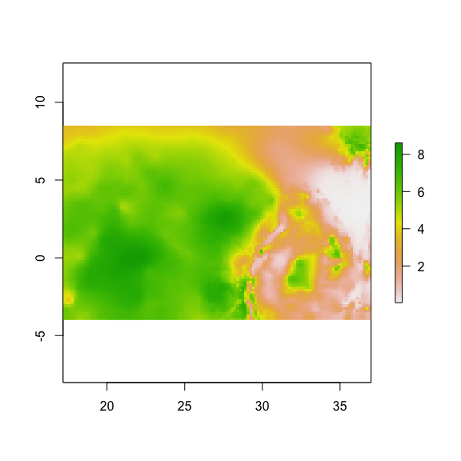

```r
PhenFUN1 <- Phen_model$model_1$predict

season_rain_rasters <-
  transform_rasters(raster_stack = FulanusEcoRasters_present$present,
                    FUN_qlist = qlist(season_rain = PhenFUN1(prec)))

# Let's convert the raster to binary

season_rain_rasters_binary <-
  calc(season_rain_rasters, function(x) ifelse(x < 0.5, 0, 1))

FulanusEcoRasters_season_rain <-
    transform_rasters(FulanusEcoRasters_present$present,
      FUN_qlist = qlist(weighted.mean(tmax, weights = season_rain_rasters_binary)))

# Length of Breeding season
plot(sum(season_rain_rasters))
```

```r
# Average Performance during breeding season
plot(FulanusEcoRasters_season_rain$weighted.mean_tmax_season_rain_rasters_binary)
```

[output not shown]

The function can also be a condition. Let’s say we are only interested on the periods when precipitation is bigger than 150.

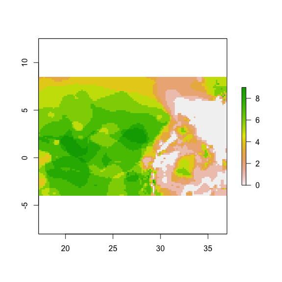

```r
PhenFUN2 <- function(x) ifelse(x > 150, 1, 0)

season_prec_rasters <-
  transform_rasters(raster_stack = FulanusEcoRasters_present$present,
    FUN_qlist = qlist(season_rain = PhenFUN2(prec)))

FulanusEcoRasters_season_prec <-
    transform_rasters(FulanusEcoRasters_present$present,
      FUN_qlist = qlist(weighted.mean(tmax, weights = season_prec_rasters)))

# Length of Breeding season
plot(sum(season_prec_rasters))
```

```r
# Average Performance during breeding season
plot(FulanusEcoRasters_season_prec)
```

[output not shown]

## Other environmental raster

Mapinguari can generate other potentially useful rasters that are not species specific, such as hydrologic variables like potential evapotranspiration, actual evapotranspiration and climatic water deficit.

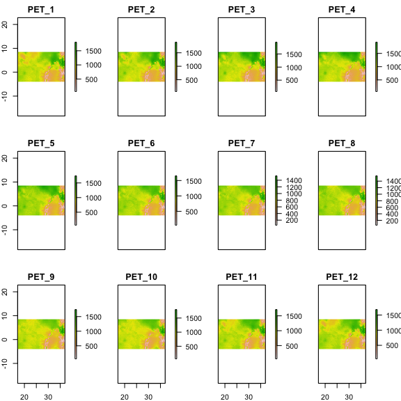

```r
prec_stack <- FulanusEcoRasters_present$present[[1:12]]
tmin_stack <- FulanusEcoRasters_present$present[[13:24]]
tmax_stack <- FulanusEcoRasters_present$present[[25:36]]
alt_stack <- FulanusEcoRasters_present$present$alt

# Potential EvapoTranspiration
PET_stack <-
PETFUN(tmax = tmax_stack,
       tmin = tmin_stack,
       alt = alt_stack)

raster::plot(PET_stack)
```

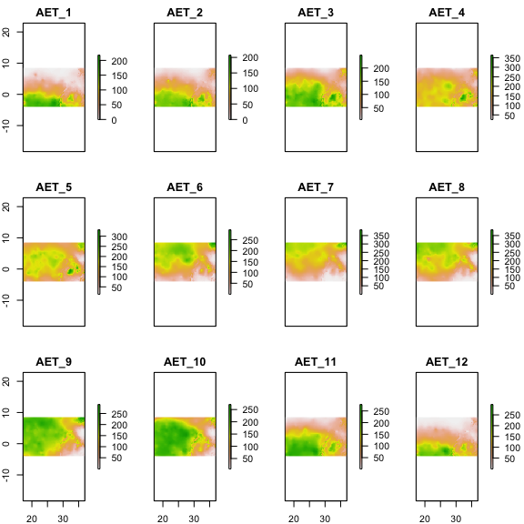

```r
# Actual EvapoTranspiration
AET_stack <-
AETFUN(PET = PET_stack, prec = prec_stack)

raster::plot(AET_stack)
```

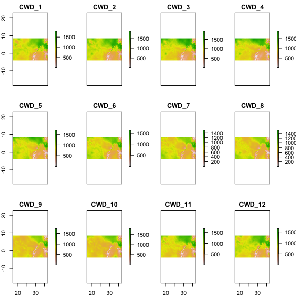

```r
# Climatic Water Deficit

CWD_stack <- PET_stack - AET_stack
names(CWD_stack) <- paste("CWD", 1:12, sep = "_")

raster::plot(CWD_stack)
```

```r
# day length

daylength_stack <- daylengthFUN(CWD_stack)
```